# Modelos de regresión dinámica

Pablo Benavides-Herrera

2020-05-04

```r
library(easypackages)
libraries("tidyverse","fpp3")
```

# Introducción

Los modelos de pronóstico de suavización exponencial y ARIMAs son estimdos **a través de observaciones pasadas**, pero **no permiten incluir información exógena** a la serie (otras variables).

Por ejemplo, para pronosticar la demanda de energía eléctrica, podemos implementar un ARIMA estacional. Sin embargo, cuánta energía se consume en los hogares se ve afectada fuertemente por la temperatura ambiental en ese momento. Con el SARIMA solo podríamos obtener la dinámica de la propia serie, pero tal vez sería bueno incluir también como predictora a la temperatura.

Recordando, un modelo de regresión tiene la forma general

$$y_{t}=\beta_{0}+\beta_{1} x_{1, t}+\cdots+\beta_{k} x_{k, t}+\varepsilon_{t}$$

donde $y_t$ es la variable que queremos pronosticar, $x_{k, t}$ son las variables independientes que utilizábamos para explicar a $y_t$ y $\varepsilon_{t}$ es el término de error no correlacionado (ruido blanco).

Para extender ese modelo, ahora permitiremos que el término de error sí esté autocorrelacionado, por lo que lo sustituimos por $\eta_t$, que asumimos que sigue un proceso ARIMA:

$$\begin{array}{c}
y_{t}=\beta_{0}+\beta_{1} x_{1, t}+\cdots+\beta_{k} x_{k, t}+\eta_{t} \\
\left(1-\phi_{1} B\right)(1-B) \eta_{t}=\left(1+\theta_{1} B\right) \varepsilon_{t}
\end{array}$$

Este modelo tiene dos términos de error: $eta_t$ (el error de la regresión) y $\varepsilon_{t}$ (el error del proceso ARIMA). Sólo $\varepsilon_{t}$ se asume que es ruido blanco.

**NOTA:** Cuando se quiere realizar un modelo de regresión dinámica, es necesario que **todas las variables sean estacionarias**, por lo que primero se debe verificar que se cumpla eso, o que se conviertan en estacionarias. De hecho, si una variable requiere primeras diferencias, es conveniente aplicar las primeras diferencias a todas las variables. A esto se le conoce como un *modelo en diferencias*. A un modelo que toma los datos originales se le conoce como *modelo en niveles*.

# Regresión con errores ARIMA en **R** con `fable`

Podemos estimar un modelo de regresion que incluya errores ARIMA a través de la misma función utilizada antes, `ARIMA`. Si definimos el argumento especial `pdq()` con primeras diferencias (`pdq(d=1)`), **R** aplicará las primeras diferencias a todas las variables.

Para incluir a las variables independientes, basta con agregarlas del lado derecho de la fórmula. P. ej:

```
ARIMA(y ~ x + pdq(1,1,0))
```

estimará un modelo en diferencias $y_{t}^{\prime}=\beta_{1} x_{t}^{\prime}+\eta_{t}^{\prime}$, donde $\eta_{t}^{\prime}=\phi_{1} \eta_{t-1}^{\prime}+\varepsilon_{t}$ es un error que sigue un proceso AR(1).

Adicionalmente, la función `ARIMA()` puede encontrar de manera automática el orden del modelo, al simplemente **no especificar el argumento especial `pdq()`**.

## Ejemplo: Consumo personal e ingreso en EEUU

Se pretende analizar y pronosticar los cambios en el consumo personal a través de el ingreso disponible, utilizando datos de 1970 a 2016.

Cargamos los datos:

```r
us_change <- read_csv("https://otexts.com/fpp3/extrafiles/us_change.csv") %>%
  mutate(Time = yearquarter(Time)) %>%
  as_tsibble(index = Time)
```

Graficamos ambas series:

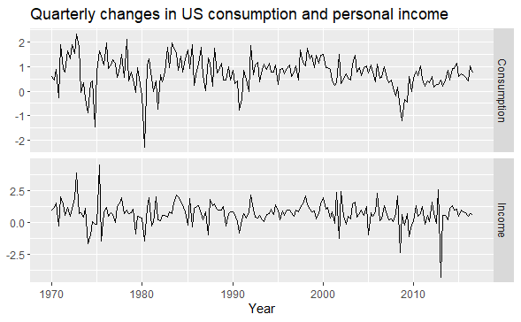

```r
us_change %>%
  gather("var", "value", Consumption, Income) %>%
  ggplot(aes(x = Time, y = value)) +
  geom_line() +
  facet_grid(vars(var), scales = "free_y") +
  xlab("Year") + ylab(NULL) +
  ggtitle("Quarterly changes in US consumption and personal income")
```

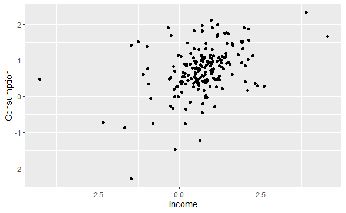

```r
us_change %>%
  ggplot(aes(x = Income, y = Consumption))+
  geom_point()
```

Las series se ven estacionarias a simple vista. Ajustamos un modelo permitiendo errores ARIMA (calculados automáticamente):

```r
fit <- us_change %>%
  model(ARIMA(Consumption ~ Income))
report(fit)
```

```
Series: Consumption
Model: LM w/ ARIMA(1,0,2) errors

Coefficients:
         ar1      ma1     ma2  Income  intercept
      0.6922  -0.5758  0.1984  0.2028     0.5990
s.e.  0.1159   0.1301  0.0756  0.0461     0.0884

sigma^2 estimated as 0.3219:  log likelihood=-156.95
AIC=325.91   AICc=326.37   BIC=345.29
```

El modelo ajustado tiene entonces la forma:

$$\begin{array}{l}
y_{t}=0.599+0.203 x_{t}+\eta_{t} \\
\eta_{t}=0.692 \eta_{t-1}+\varepsilon_{t}-0.576 \varepsilon_{t-1}+0.198 \varepsilon_{t-2} \\
\varepsilon_{t} \sim \mathrm{NID}(0,0.322)
\end{array}$$

Podemos obtener los estimadores de las series $eta_t$ y $\varepsilon_{t}$ con la función `residuals()`, especificando el tipo como `type = "regression"` para los errores de la regresión y `type = "innovations"` para los errores ARIMA.

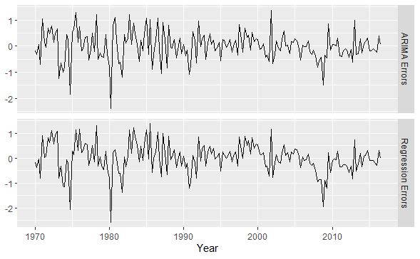

```r
bind_rows(
  `Regression Errors` = residuals(fit, type="regression"),
  `ARIMA Errors` = residuals(fit, type="innovation"),
  .id = "type"
) %>%
  ggplot(aes(x = Time, y = .resid)) +
  geom_line() +
  facet_grid(vars(type), scales = "free_y") +
  xlab("Year") + ylab(NULL)
```

Solo debemos asegurarnos de que los errores ARIMA sean ruido blanco:

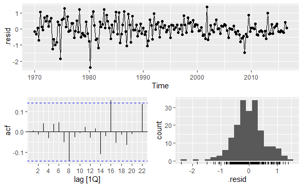

```r
fit %>% gg_tsresiduals()
```

La prueba de Ljung-Box:

```r
augment(fit) %>%
  features(.resid, ljung_box, dof = 5, lag = 8)
```

| .model | lb_stat | lb_pvalue |
| --- | --- | --- |
| ARIMA(Consumption ~ Income) | 5.891628 | 0.1170034 |

# Pronóstico

Para llevar a cabo pronósticos de modelos de regresión con errores ARIMA, se necesita realizar el pronóstico de

- la parte de la regresión
- la parte de los errores ARIMA

y combinar los resultados.

Una característica con estos modelos, es que necesitamos pronósticos de las variables independientes $x_t$ o predictoras para poder pronosticar nuestra variable de interés, $y_t$. Cuando las predictoras son conocidas en el futuro, como variables de calendario (tiempo, día de la semana, mes, etc.), no hay mayor problema. Pero, cuando son desconocidas, tenemos que o modelarlas por separado, o asumir valores futuros para cada una.

## Continuación ejemplo: Consumo personal e ingreso en EEUU

Obtenemos pronósticos para los siguientes dos años (8 trimestres), asumiendo que los cambios porcentuales en el ingreso serán iguales a el cambio promedio porcentual de los últimos 40 años:

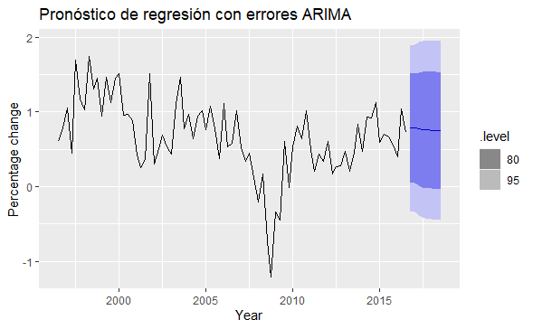

```r
us_change_future <- new_data(us_change, 8) %>% mutate(Income = mean(us_change$Income))
forecast(fit, new_data = us_change_future) %>%
  autoplot(slice(us_change, (n()-80):n())) + xlab("Year") +
  ylab("Percentage change") + ggtitle("Pronóstico de regresión con errores ARIMA")
```

Cuando vimos los modelos ARIMA no estacionales, habíamos analizado esta misma serie. Recordando, el pronóstico resultaba:

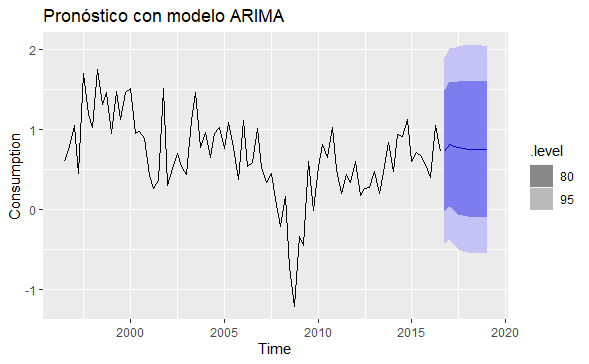

```r
fit_prev <- us_change %>%
  model(ARIMA(Consumption ~ PDQ(0,0,0)))

fit_prev %>% forecast(h=10) %>% autoplot(slice(us_change, (n()-80):n())) + ggtitle("Pronóstico con modelo ARIMA")
```

La principal diferencia entre ambas es que, con nuestro nuevo modelo, logramos capturar más información y, por lo tanto, los intervalos de predicción se reducen.

**NOTA:** Los intervalos de predicción de modelos de regresión (regresión lineal múltiple o modelos con errores ARIMA), no toman en cuenta la incertidumbre de las predictoras. Así, el modelo *asume* que esas predicciones son correctas. En otras palabras, los intervalos de predicción son condicionales al cumplimiento de los valores de las predictoras.

## Ejemplo: Demanda de energía

La demanda de energía diaria se puede modelar como una función de la temperatura del ambiente. Cuando la temperatura es muy extrema (muy alta o muy baja), tiende a aumentar la demanda de energía (por el uso de aires acondicionados y calefacción, respectivamente).

Grafiquemos la energía demandada vs. la temperatura global de cada día para ver este efecto:

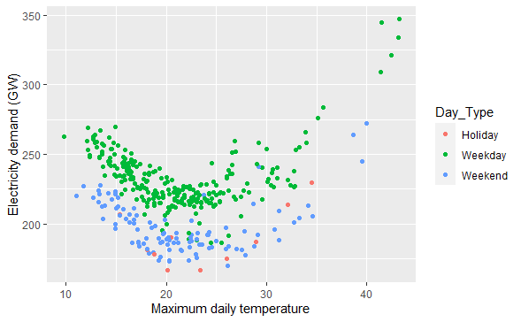

```r
vic_elec_daily <- vic_elec %>%
  filter(year(Time) == 2014) %>%
  index_by(Date = date(Time)) %>%
  summarise(
    Demand = sum(Demand)/1e3,
    Temperature = max(Temperature),
    Holiday = any(Holiday)
  ) %>%
  mutate(Day_Type = case_when(
    Holiday ~ "Holiday",
    wday(Date) %in% 2:6 ~ "Weekday",
    TRUE ~ "Weekend"
  ))

vic_elec_daily %>%
  ggplot(aes(x=Temperature, y=Demand, colour=Day_Type)) +
    geom_point() +
    ylab("Electricity demand (GW)") +
    xlab("Maximum daily temperature")
```

Ahora revisamos las gráficas de tiempo de ambas variables:

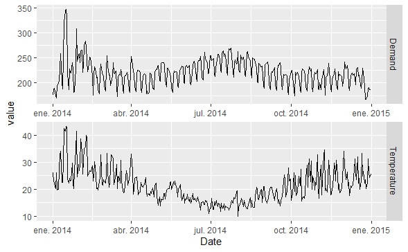

```r
vic_elec_daily %>%
  pivot_longer(cols = c(Demand, Temperature), names_to = "vars",
               values_to = "value") %>%
  ggplot(aes(x = Date, y = value)) +
  geom_line() +
  facet_wrap(~ vars, ncol = 1, strip.position = "right", scales = "free")
```

Dado que la relación entre las variables es cuadrática, ajustaremos un modelo cuadrático con errores ARIMA. Adicionalmente, agregaremos una variable para indicar si el día fue hábil o no.

```r
fit <- vic_elec_daily %>%
  model(ARIMA(Demand ~ Temperature + I(Temperature^2) + (Day_Type=="Weekday")))

report(fit)
```

```
Series: Demand
Model: LM w/ ARIMA(2,1,2)(0,0,2)[7] errors

Coefficients:
         ar1      ar2      ma1     ma2    sma1    sma2
      1.1521  -0.2750  -1.3851  0.4071  0.1589  0.3103
s.e.  0.6265   0.4812   0.6082  0.5805  0.0591  0.0538
      Temperature  I(Temperature^2)  Day_Type == "Weekday"TRUE
          -7.9467            0.1865                    31.8245
s.e.       0.4920            0.0097                     1.0189

sigma^2 estimated as 48.82:  log likelihood=-1220.48
AIC=2460.96   AICc=2461.58   BIC=2499.93
```

Revisamos el ajuste del modelo a través de sus residuos:

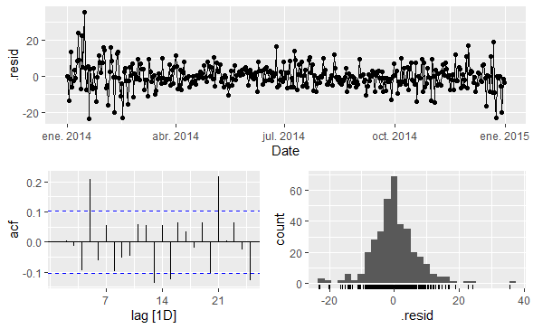

```r
fit %>% gg_tsresiduals()
```

```r
augment(fit) %>%
  features(.resid, ljung_box, dof = 8, lag = 14)
```

| .model | lb_stat | lb_pvalue |
| --- | --- | --- |
| ARIMA(Demand ~ Temperature + I(Temperature^2) + (Day_Type == \n "Weekday")) | 38.13947 | 1.054994e-06 |

Se ven heteroscedásticos, ya que la variación es mayor en enero y un poco en febrero que en otros meses. Adicionalmente, vemos que hay rezagos significativos y que la distribución es de colas largas. Esto puede tener un impacto negativo en los intervalos de predicción, pero la estimación puntual es válida.

Así, entonces pronosticaremos los siguientes 14 días. Para esto, necesitamos datos respecto a la temperatura futura y podemos hacer dos cosas:

- Conseguir los datos de algún pronóstico meteorológico y meterlos al modelo.
- Podemos pronosticar bajo un escenario. Asumiremos que la temperatura máxima se mantendrá constante a 26 grados.

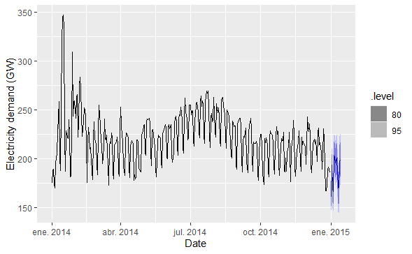

```r
vic_elec_future <- new_data(vic_elec_daily, 14) %>%
  mutate(
    Temperature = 26,
    Holiday = c(TRUE, rep(FALSE, 13)),
    Day_Type = case_when(
      Holiday ~ "Holiday",
      wday(Date) %in% 2:6 ~ "Weekday",
      TRUE ~ "Weekend"
    )
  )
forecast(fit, vic_elec_future) %>%
  autoplot(vic_elec_daily) + ylab("Electricity demand (GW)")
```

Utilizando un pronóstico de la temperatura máxima para los siguientes 14 días tendríamos:

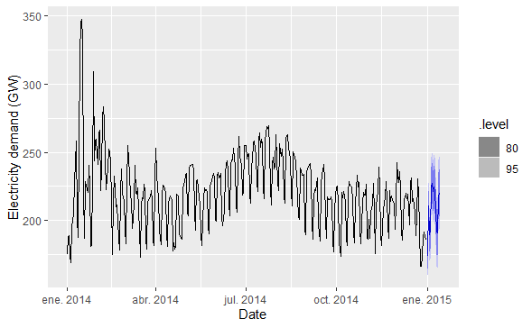

```r
vic_elec_future <- new_data(vic_elec_daily, 14) %>%
  mutate(
    Temperature = c(seq(31,34),33,rep(34,3),rep(33,6)),
    Holiday = c(TRUE, rep(FALSE, 13)),
    Day_Type = case_when(
      Holiday ~ "Holiday",
      wday(Date) %in% 2:6 ~ "Weekday",
      TRUE ~ "Weekend"
    )
  )
forecast(fit, vic_elec_future) %>%
  autoplot(vic_elec_daily) + ylab("Electricity demand (GW)")
```